# Introduction to Data Visualization with Seaborn

Lecturers: Yashas Roy, Mona Khalil

It is recommended that you take the course [**Introduction to Data Science in Python** prior to this course.](https://quannguyeniu.github.io/DataCamp/Python/Intro_Data_Science_Python.html)

# 1 Course Description

Seaborn is a powerful Python library that makes it easy to create informative and attractive data visualizations. This 4-hour course provides an introduction to how you can use Seaborn to create a variety of plots, including scatter plots, count plots, bar plots, and box plots, and how you can customize your visualizations.

You’ll explore this library and create Seaborn plots based on a variety of real-world data sets, including exploring how air pollution in a city changes through the day and looking at what young people like to do in their free time. This data will give you the opportunity to find out about Seaborn’s advantages first hand, including how you can easily create subplots in a single figure and how to automatically calculate confidence intervals.

By the end of this course, you’ll be able to use Seaborn in various situations to explore your data and effectively communicate the results of your data analysis to others. These skills are highly sought-after for data analysts, data scientists, and any other job that may involve creating data visualizations.

Course materials can be found [**here**.](https://github.com/QuanNguyenIU/QuanNguyenIU.github.io/tree/main/DataCamp/Python/Intro.%20to%20Data%20Visualization%20with%20Seaborn)

# 2 Introduction to Seaborn

## 2.1 Lecture: Introduction to Seaborn

[video not shown]

## 2.2 Making a scatter plot with lists

In this exercise, we’ll use a dataset that contains information about 227 countries. This dataset has lots of interesting information on each country, such as the country’s birth rates, death rates, and its gross domestic product (GDP). GDP is the value of all the goods and services produced in a year, expressed as dollars per person.

We’ve created three lists of data from this dataset to get you started. [**gdp** is a list that contains the value of GDP per country, expressed as dollars per person. [**phones** is a list of the number of mobile phones per 1,000 people in that country. Finally, [**percent_literate** is a list that contains the percent of each country’s population that can read and write.](https://raw.githubusercontent.com/QuanNguyenIU/QuanNguyenIU.github.io/main/DataCamp/Python/Intro.%20to%20Data%20Visualization%20with%20Seaborn/percent_literate.csv)](https://raw.githubusercontent.com/QuanNguyenIU/QuanNguyenIU.github.io/main/DataCamp/Python/Intro.%20to%20Data%20Visualization%20with%20Seaborn/phones.csv)](https://raw.githubusercontent.com/QuanNguyenIU/QuanNguyenIU.github.io/main/DataCamp/Python/Intro.%20to%20Data%20Visualization%20with%20Seaborn/gdp.csv)

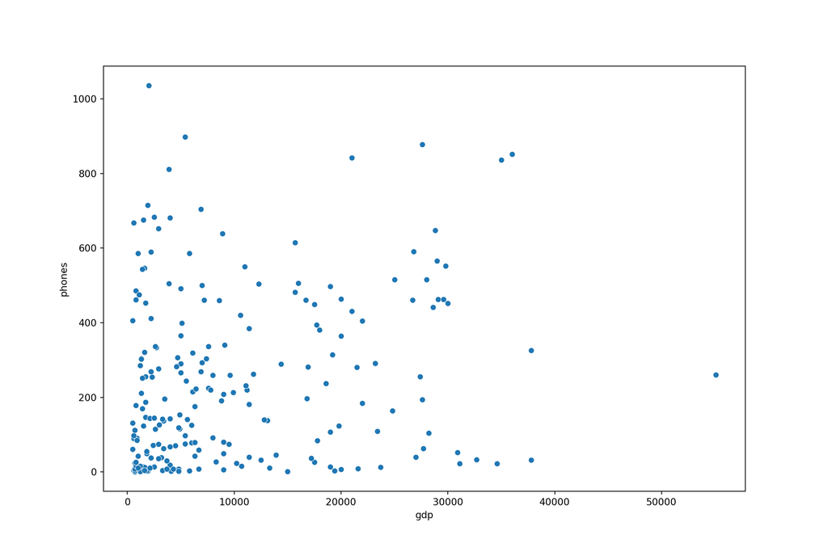

```python
import pandas as pd
url = 'https://raw.githubusercontent.com/QuanNguyenIU/QuanNguyenIU.github.io/main/DataCamp/Python/Intro.%20to%20Data%20Visualization%20with%20Seaborn/gdp.csv'
gdp = pd.read_csv(url)['gdp']
url = 'https://raw.githubusercontent.com/QuanNguyenIU/QuanNguyenIU.github.io/main/DataCamp/Python/Intro.%20to%20Data%20Visualization%20with%20Seaborn/phones.csv'
phones = pd.read_csv(url)['phones']
url = 'https://raw.githubusercontent.com/QuanNguyenIU/QuanNguyenIU.github.io/main/DataCamp/Python/Intro.%20to%20Data%20Visualization%20with%20Seaborn/percent_literate.csv'
percent_literate = pd.read_csv(url)['percent_literate']

# Import Matplotlib and Seaborn
import matplotlib.pyplot as plt
import seaborn as sns

# Create scatter plot with GDP on the x-axis and number of phones on the y-axis
sns.scatterplot(x = gdp, y = phones)

# Show plot
plt.show()
```

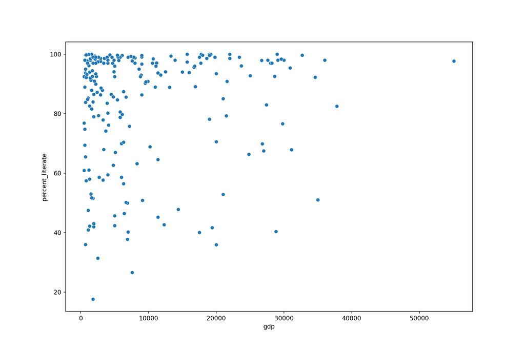

```python
# Change this scatter plot to have percent literate on the y-axis
sns.scatterplot(x = gdp, y = percent_literate)

# Show plot
plt.show()
```

While this plot does not show a linear relationship between GDP and percent literate, countries with a lower GDP do seem more likely to have a lower percent of the population that can read and write.

## 2.3 Making a count plot with a list

In the last exercise, we explored a dataset that contains information about 227 countries. Let’s do more exploration of this data - specifically, how many countries are in each region of the world?

To do this, we’ll need to use a count plot. Count plots take in a categorical list and return bars that represent the number of list entries per category. You can create one here using a list of regions for each country, which is a variable named [**region**.](https://raw.githubusercontent.com/QuanNguyenIU/QuanNguyenIU.github.io/main/DataCamp/Python/Intro.%20to%20Data%20Visualization%20with%20Seaborn/region.csv)

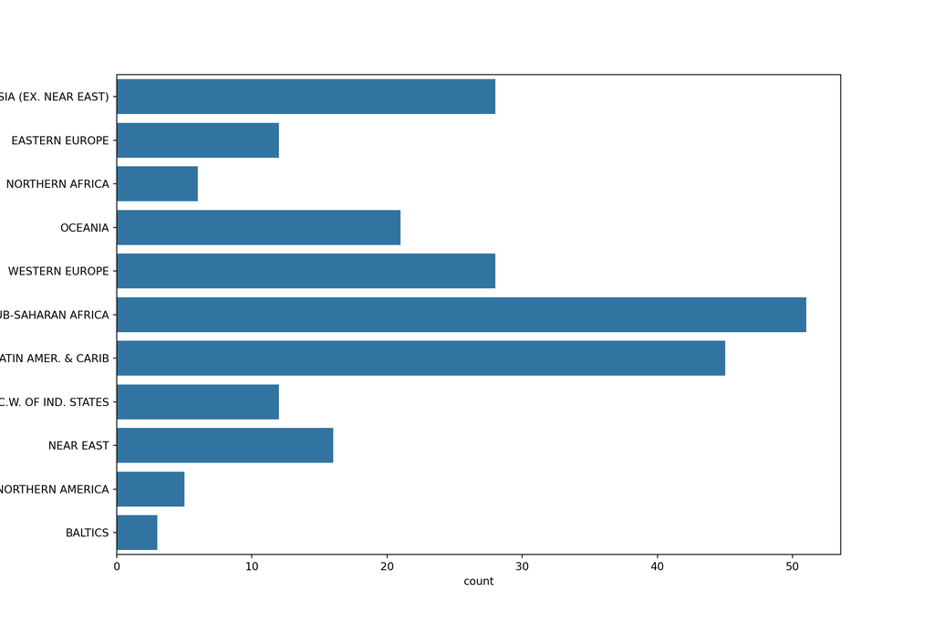

```python
url = 'https://raw.githubusercontent.com/QuanNguyenIU/QuanNguyenIU.github.io/main/DataCamp/Python/Intro.%20to%20Data%20Visualization%20with%20Seaborn/region.csv'
region = pd.read_csv(url)['region']

# Create count plot with region on the y-axis
sns.countplot(y = region)

# Show plot
plt.show()
```

Sub-Saharan Africa contains the most countries in this list. We’ll revisit count plots later in the course.

## 2.4 Lecture: Using pandas with Seaborn

[video not shown]

## 2.5 “Tidy” vs. “untidy” data

Here, we have a sample dataset from a survey of children about their favorite animals. But can we use this dataset as-is with Seaborn? Let’s use pandas to import the csv file with the data collected from the survey and determine whether it is tidy, which is essential to having it work well with Seaborn.

To get you started, the filepath to the csv file has been assigned to the variable **csv_filepath**.

Note that because **csv_filepath** is a Python variable, you will not need to put quotation marks around it when you read the csv.

```python
csv_filepath = 'https://raw.githubusercontent.com/QuanNguyenIU/QuanNguyenIU.github.io/main/DataCamp/Python/Intro.%20to%20Data%20Visualization%20with%20Seaborn/1.2.1_example_csv.csv'

# Create a DataFrame from csv file
df= pd.read_csv(csv_filepath)

# Print the head of df
print(df.head())
```

```
##   Unnamed: 0               How old are you?
## 0     Marion                             12
## 1      Elroy                             16
## 2        NaN  What is your favorite animal?
## 3     Marion                            dog
## 4      Elroy                            cat
```

The DataFrame is untidy, because a single column contains different types of information. Always make sure to check if your DataFrame is tidy before using it with Seaborn.

## 2.6 Making a count plot with a DataFrame

In this exercise, we’ll look at the [**responses** to a survey sent out to young people. Our primary question here is: how many young people surveyed report being scared of spiders? Survey participants were asked to agree or disagree with the statement “I am afraid of spiders”. Responses vary from 1 to 5, where 1 is “Strongly disagree” and 5 is “Strongly agree”.](https://raw.githubusercontent.com/QuanNguyenIU/QuanNguyenIU.github.io/main/DataCamp/Python/Intro.%20to%20Data%20Visualization%20with%20Seaborn/young-people-survey-responses.csv)

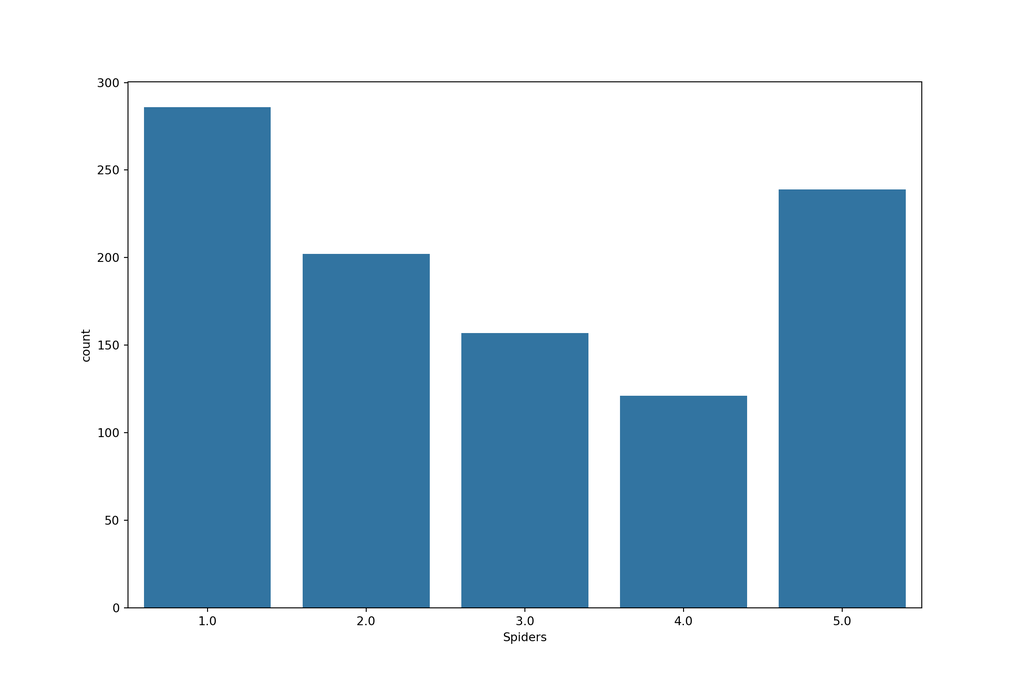

```python
url = 'https://raw.githubusercontent.com/QuanNguyenIU/QuanNguyenIU.github.io/main/DataCamp/Python/Intro.%20to%20Data%20Visualization%20with%20Seaborn/young-people-survey-responses.csv'
df = pd.read_csv(url)

# Create a count plot with "Spiders" on the x-axis
sns.countplot(x = "Spiders",data = df)

# Display the plot
plt.show()
```

This plot shows us that most young people reported not being afraid of spiders.

## 2.7 Lecture: Adding a third variable with hue

[video not shown]

## 2.8 Hue and scatter plots

In the prior video, we learned how hue allows us to easily make subgroups within Seaborn plots. Let’s try it out by exploring [**data from students in secondary school**. We have a lot of information about each student like their age, where they live, their study habits and their extracurricular activities.](https://raw.githubusercontent.com/QuanNguyenIU/QuanNguyenIU.github.io/main/DataCamp/Python/Intro.%20to%20Data%20Visualization%20with%20Seaborn/student_data.csv)

For now, we’ll look at the relationship between the number of absences they have in school and their final grade in the course, segmented by where the student lives (rural vs. urban area).

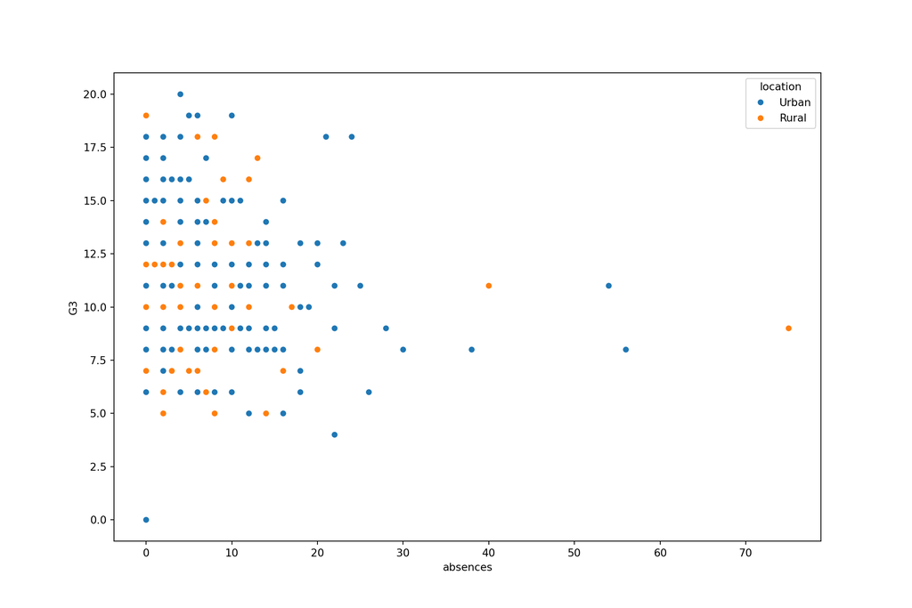

```python
url = 'https://raw.githubusercontent.com/QuanNguyenIU/QuanNguyenIU.github.io/main/DataCamp/Python/Intro.%20to%20Data%20Visualization%20with%20Seaborn/student_data.csv'
student_data = pd.read_csv(url)

# Create a scatter plot of absences vs. final grade
sns.scatterplot(data = student_data, x = "absences", y = "G3", hue = "location")

# Show plot
plt.show()
```

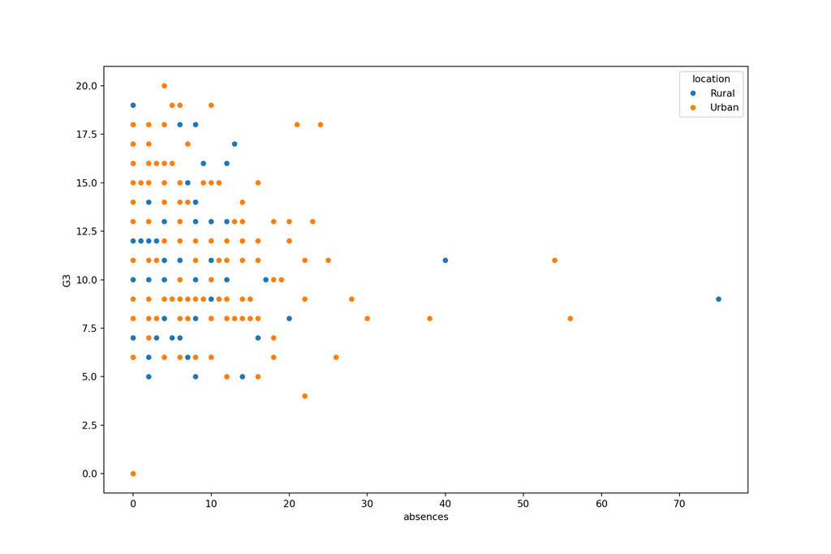

```python
# Change the legend order in the scatter plot
sns.scatterplot(x = "absences", y = "G3",
                data = student_data,
                hue = "location", hue_order = ['Rural', 'Urban'])

# Show plot
plt.show()
```

It looks like students with higher absences tend to have lower grades in both rural and urban areas.

## 2.9 Hue and count plots

Let’s continue exploring our dataset from students in secondary school by looking at a new variable. The “school” column indicates the initials of which school the student attended - either “GP” or “MS”.

In the last exercise, we created a scatter plot where the plot points were colored based on whether the student lived in an urban or rural area. How many students live in urban vs. rural areas, and does this vary based on what school the student attends? Let’s make a count plot with subgroups to find out.

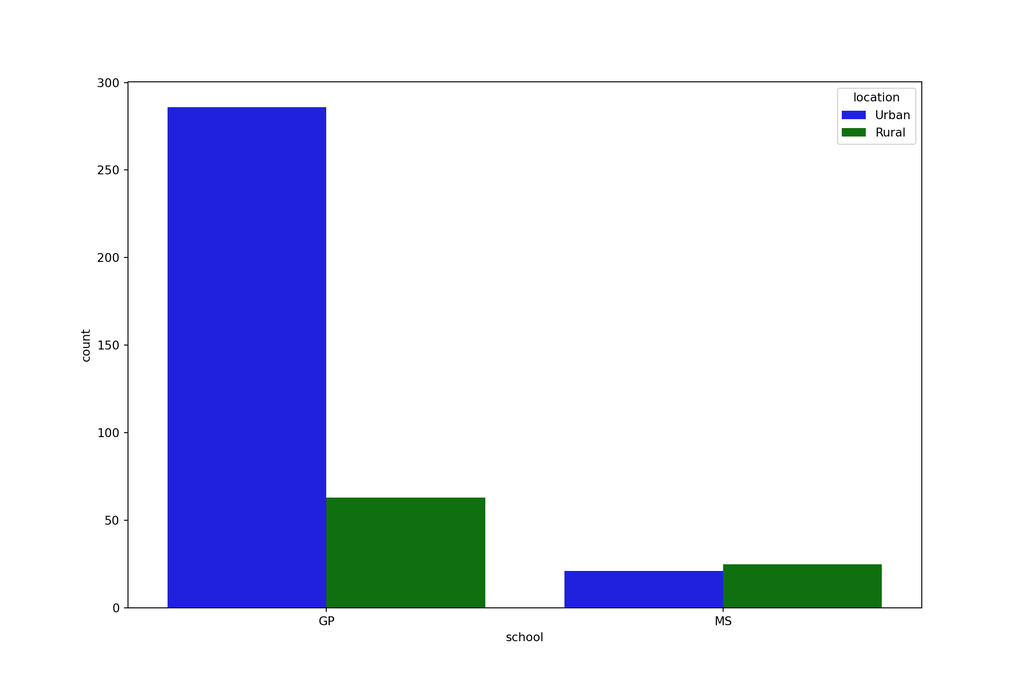

```python
# Create a dictionary mapping subgroup values to colors
palette_colors = {"Rural": "green", "Urban": "blue"}

# Create a count plot of school with location subgroups
sns.countplot(data = student_data, x = "school", hue = "location", palette = palette_colors)

# Display plot
plt.show()
```

Students at GP tend to come from an urban location, but students at MS are more evenly split.

# 3 Visualizing Two Quantitative Variables

## 3.1 Lecture: Introduction to relational plots and subplots

[video not shown]

## 3.2 Creating subplots with col and row

We’ve seen in prior exercises that students with more absences (“absences”) tend to have lower final grades (“G3”). Does this relationship hold regardless of how much time students study each week?

To answer this, we’ll look at the relationship between the number of absences that a student has in school and their final grade in the course, creating separate subplots based on each student’s weekly study time (“study_time”).

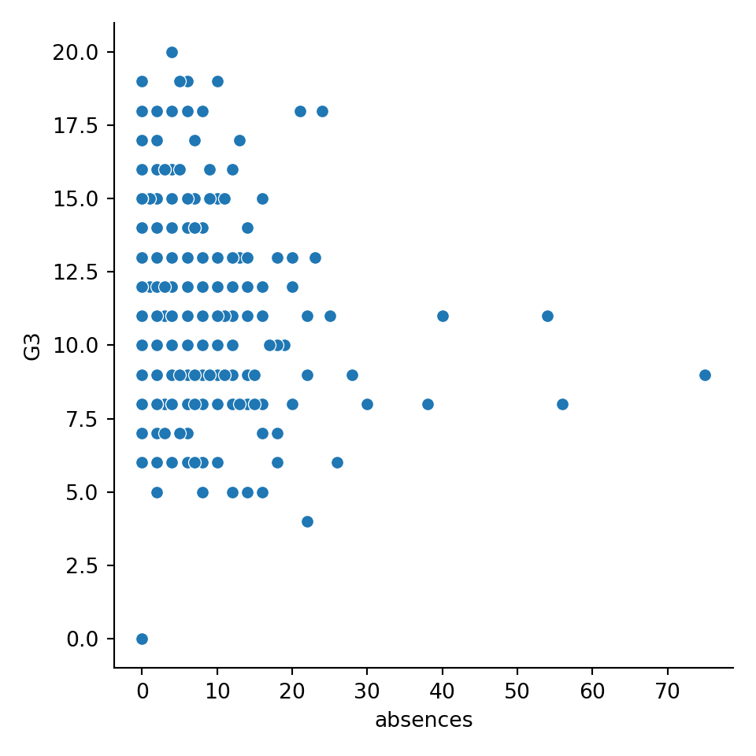

```python
# Change to use relplot() instead of scatterplot()
g = sns.relplot(x = "absences", y = "G3",
                data = student_data, kind = "scatter")

# Show plot
plt.show()
```

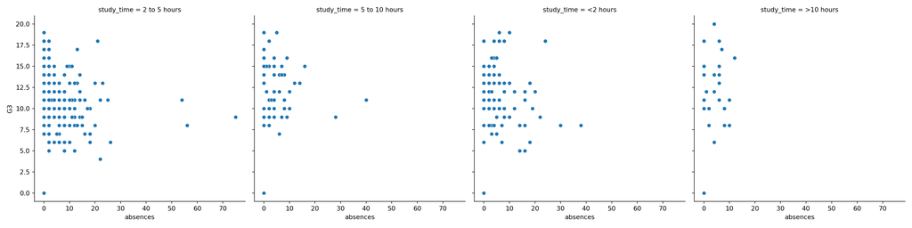

```python
# Change to make subplots based on study time
g = sns.relplot(x = "absences", y = "G3",
                data = student_data,
                kind = "scatter",col = "study_time")

# Show plot
plt.show()
```

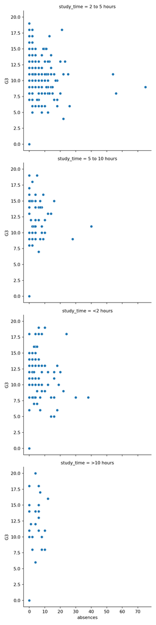

```python
# Change to arrange the plots in rows instead of columns
g = sns.relplot(x = "absences", y = "G3",
                data = student_data,
                kind = "scatter", row = "study_time")

# Show plot
plt.show()
```

Because these subplots had a large range of x values, it’s easier to read them arranged in rows instead of columns.

## 3.3 Creating two-factor subplots

Let’s continue looking at the **student_data** dataset of students in secondary school. Here, we want to answer the following question: does a student’s first semester grade (“G1”) tend to correlate with their final grade (“G3”)?

There are many aspects of a student’s life that could result in a higher or lower final grade in the class. For example, some students receive extra educational support from their school (“schoolsup”) or from their family (“famsup”), which could result in higher grades. Let’s try to control for these two factors by creating subplots based on whether the student received extra educational support from their school or family.

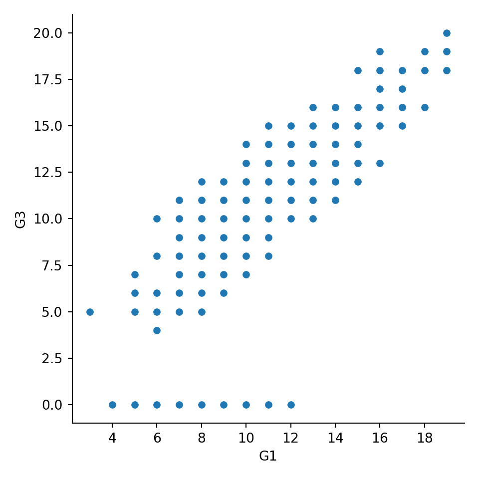

```python
# Create a scatter plot of G1 vs. G3
g = sns.relplot(data = student_data, x = "G1", y = "G3", kind = "scatter")

# Show plot
plt.show()
```

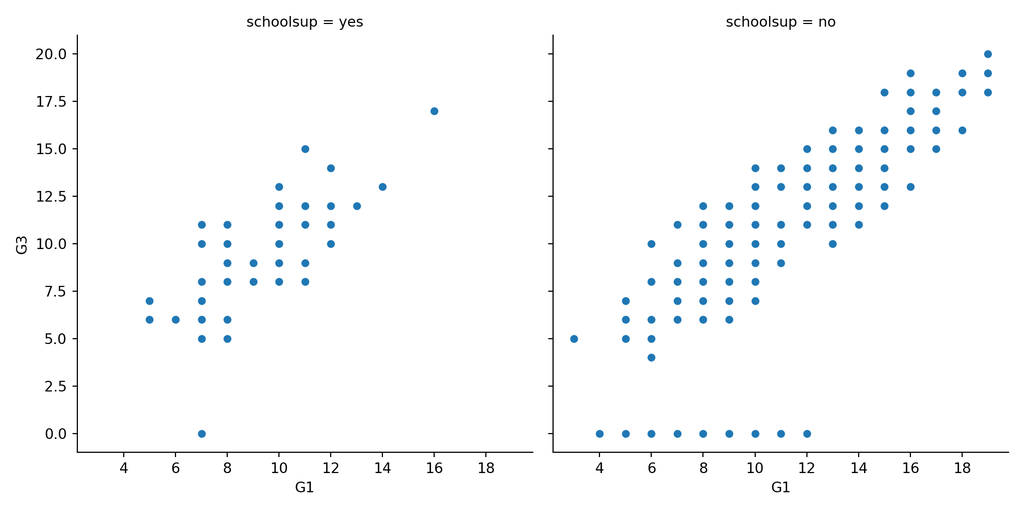

```python
# Adjust to add subplots based on school support
g = sns.relplot(x = "G1", y = "G3",
            data = student_data,
            kind = "scatter", col = "schoolsup", col_order = ["yes", "no"])

# Show plot
plt.show()
```

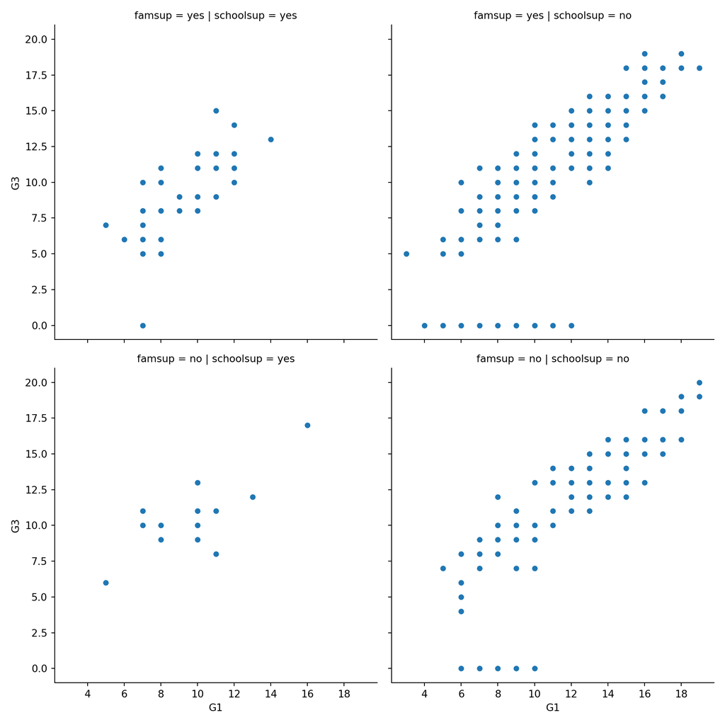

```python
# Adjust further to add subplots based on family support
g = sns.relplot(x = "G1", y = "G3",
                data = student_data,
                kind = "scatter",
                col = "schoolsup", col_order = ["yes", "no"],
                row = "famsup", row_order = ["yes", "no"])

# Show plot
plt.show()
```

It looks like the first semester grade does correlate with the final grade, regardless of what kind of support the student received.

## 3.4 Lecture: Customizing scatter plots

[video not shown]

## 3.5 Changing the size of scatter plot points

In this exercise, we’ll explore Seaborn’s [**mpg** dataset, which contains one row per car model and includes information such as the year the car was made, the number of miles per gallon (“M.P.G.”) it achieves, the power of its engine (measured in “horsepower”), and its country of origin.](https://raw.githubusercontent.com/QuanNguyenIU/QuanNguyenIU.github.io/main/DataCamp/Python/Intro.%20to%20Data%20Visualization%20with%20Seaborn/mpg.csv)

What is the relationship between the power of a car’s engine (“horsepower”) and its fuel efficiency (“mpg”)? And how does this relationship vary by the number of cylinders (“cylinders”) the car has? Let’s find out.

Let’s continue to use relplot() instead of scatterplot() since it offers more flexibility.

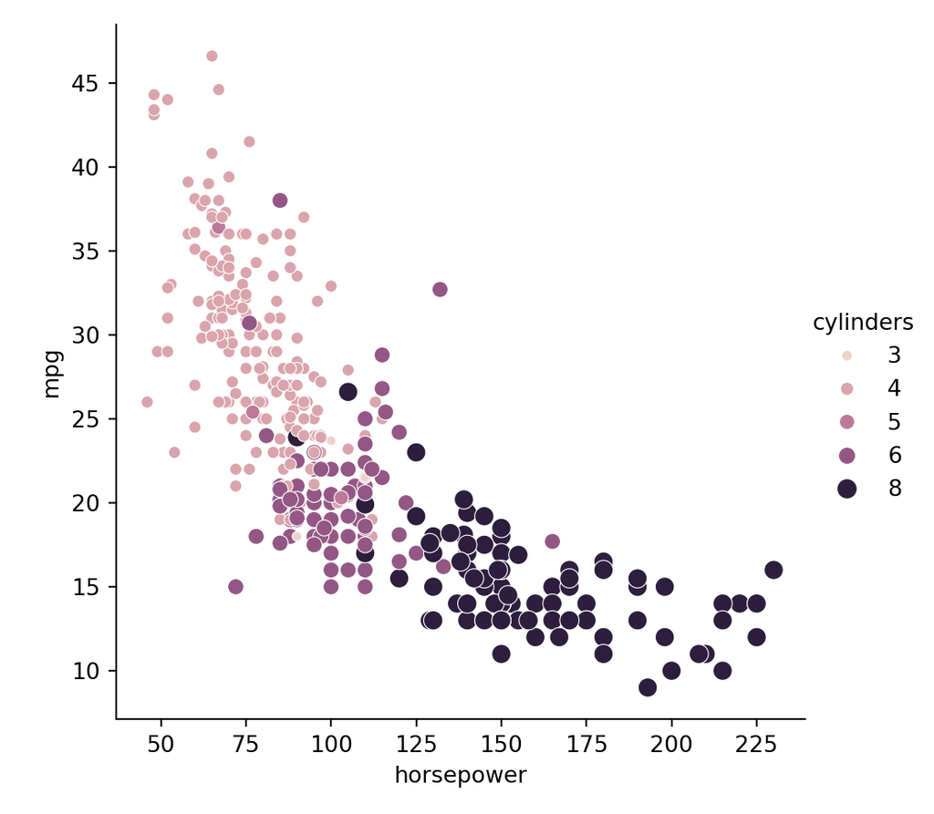

```python
url = 'https://raw.githubusercontent.com/QuanNguyenIU/QuanNguyenIU.github.io/main/DataCamp/Python/Intro.%20to%20Data%20Visualization%20with%20Seaborn/mpg.csv'
mpg = pd.read_csv(url)

# Create scatter plot of horsepower vs. mpg
g = sns.relplot(x = "horsepower", y = "mpg",
                data = mpg, kind = "scatter",
                size = "cylinders", hue = "cylinders")

# Show plot
plt.show()
```

Cars with higher horsepower tend to get a lower number of miles per gallon. They also tend to have a higher number of cylinders.

## 3.6 Changing the style of scatter plot points

Let’s continue exploring Seaborn’s mpg dataset by looking at the relationship between how fast a car can accelerate (“acceleration”) and its fuel efficiency (“mpg”). Do these properties vary by country of origin (“origin”)?

Note that the “acceleration” variable is the time to accelerate from 0 to 60 miles per hour, in seconds. Higher values indicate slower acceleration.

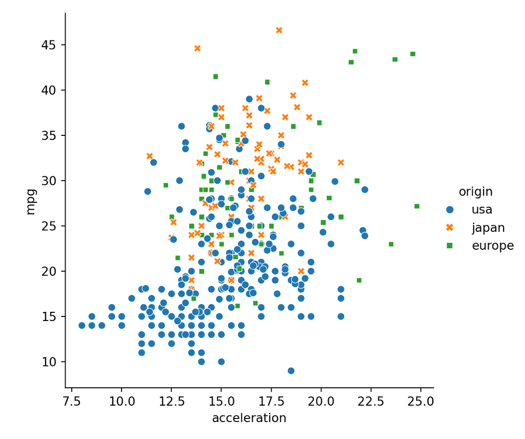

```python
# Create a scatter plot of acceleration vs. mpg
g = sns.relplot(data = mpg, x = "acceleration", y = "mpg",
                kind = "scatter", hue = "origin", style = "origin")

# Show plot
plt.show()
```

Cars from the USA tend to accelerate more quickly and get lower miles per gallon compared to cars from Europe and Japan.

## 3.7 Lecture: Introduction to line plots

[video not shown]

## 3.8 Interpreting line plots

In this exercise, we’ll continue to explore Seaborn’s mpg dataset, which contains one row per car model and includes information such as the year the car was made, its fuel efficiency (measured in “miles per gallon” or “M.P.G”), and its country of origin (USA, Europe, or Japan).

How has the average miles per gallon achieved by these cars changed over time? Let’s use line plots to find out!

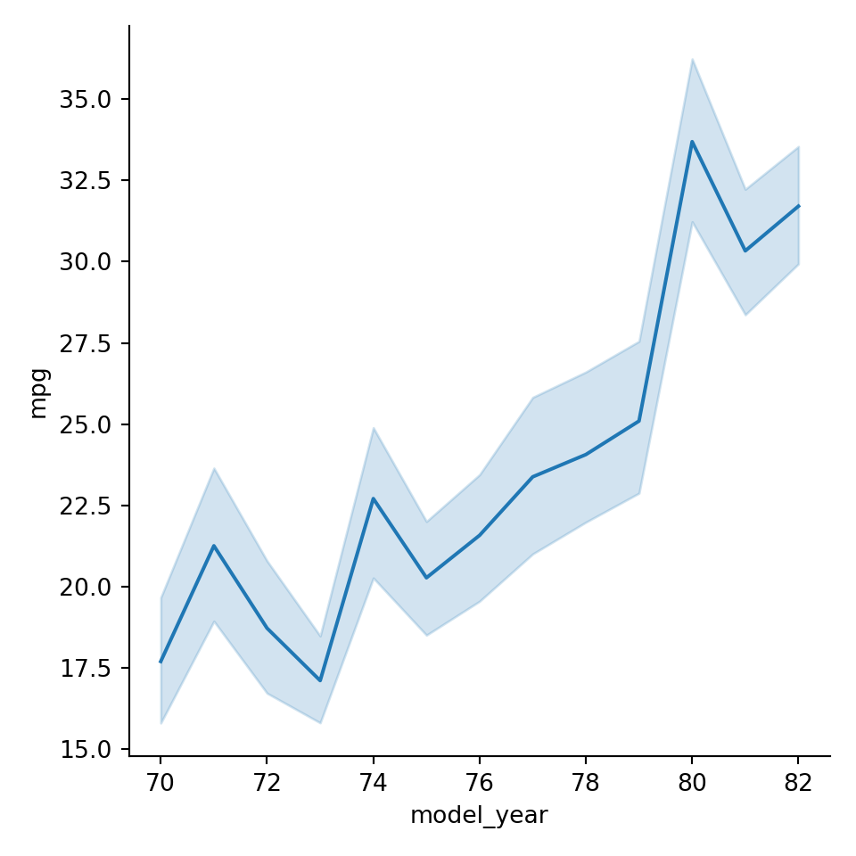

```python
# Create line plot
g = sns.relplot(data = mpg, x = "model_year", y = "mpg", kind = "line")

# Show plot
plt.show()
```

Note that the shaded region represents a confidence interval for the mean, not the distribution of the observations.

## 3.9 Visualizing standard deviation with line plots

In the last exercise, we looked at how the average miles per gallon achieved by cars has changed over time. Now let’s use a line plot to visualize how the distribution of miles per gallon has changed over time.

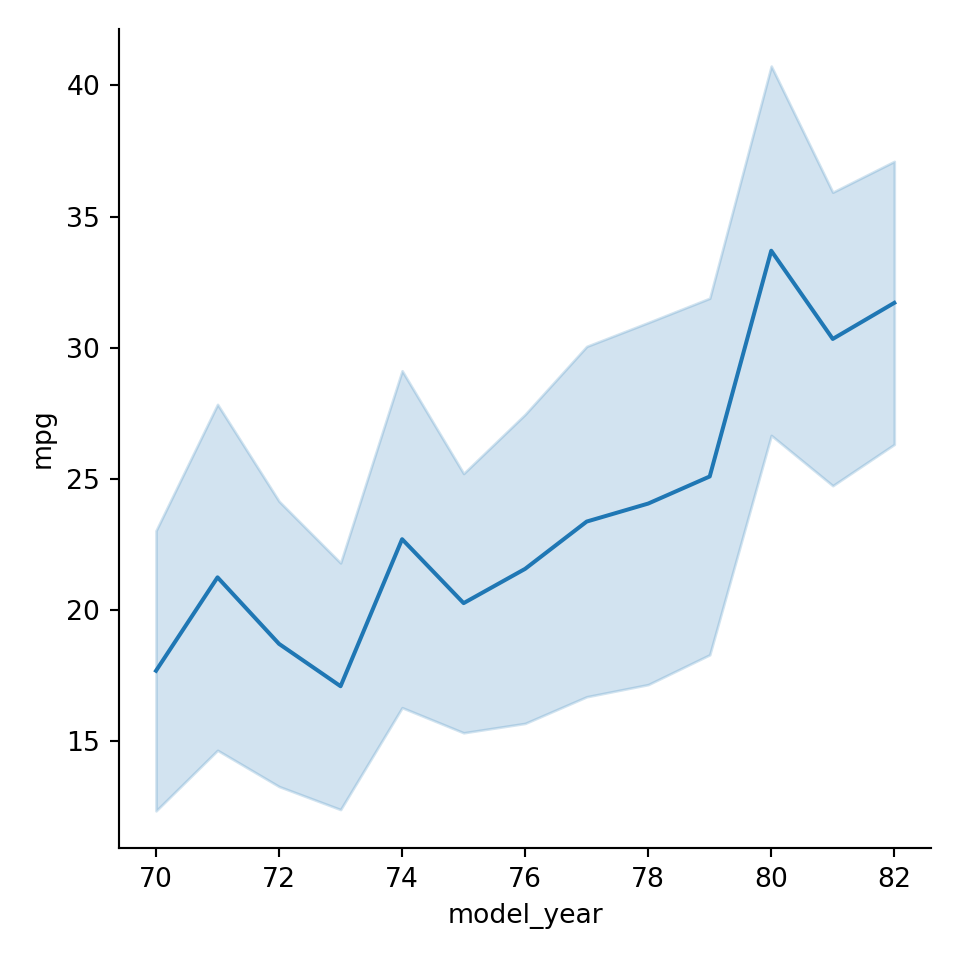

```python
# Make the shaded area show the standard deviation
g = sns.relplot(x = "model_year", y = "mpg",
                data = mpg, kind = "line", ci = 'sd')

# Show plot
plt.show()
```

Unlike the plot in the last exercise, this plot shows us the distribution of miles per gallon for all the cars in each year.

## 3.10 Plotting subgroups in line plots

Let’s continue to look at the mpg dataset. We’ve seen that the average miles per gallon for cars has increased over time, but how has the average horsepower for cars changed over time? And does this trend differ by country of origin?

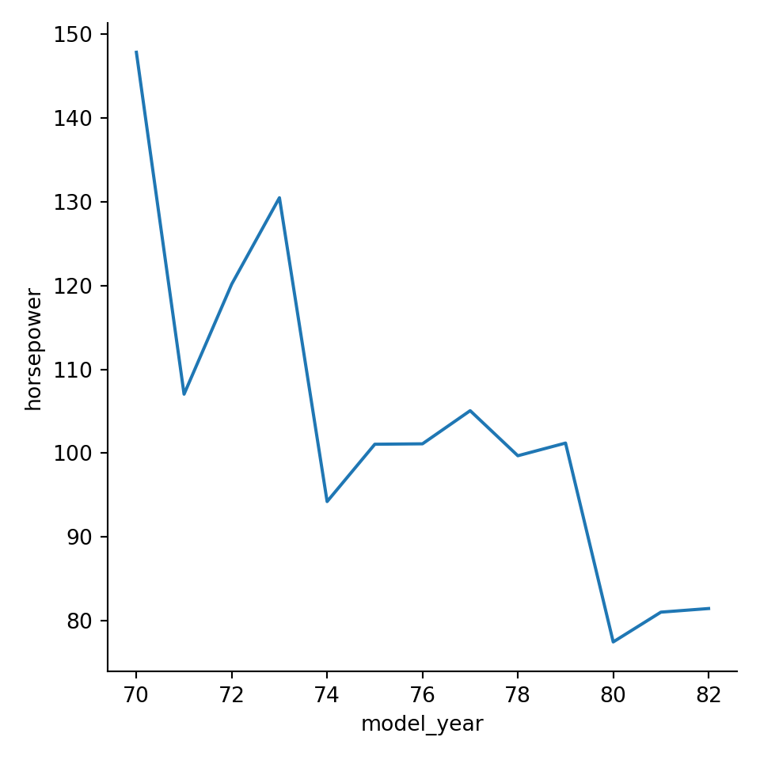

```python
# Create line plot of model year vs. horsepower
g = sns.relplot(data = mpg, x = "model_year", y = "horsepower",
                kind = "line", ci = None)

# Show plot
plt.show()
```

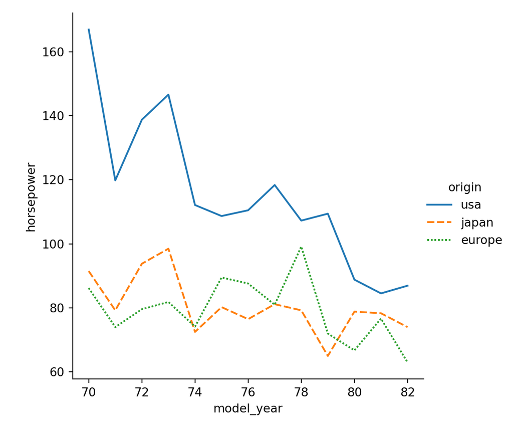

```python
# Change to create subgroups for country of origin
g = sns.relplot(x = "model_year", y = "horsepower",
                data = mpg, kind = "line",
                ci = None, style = "origin", hue = "origin")

# Show plot
plt.show()
```

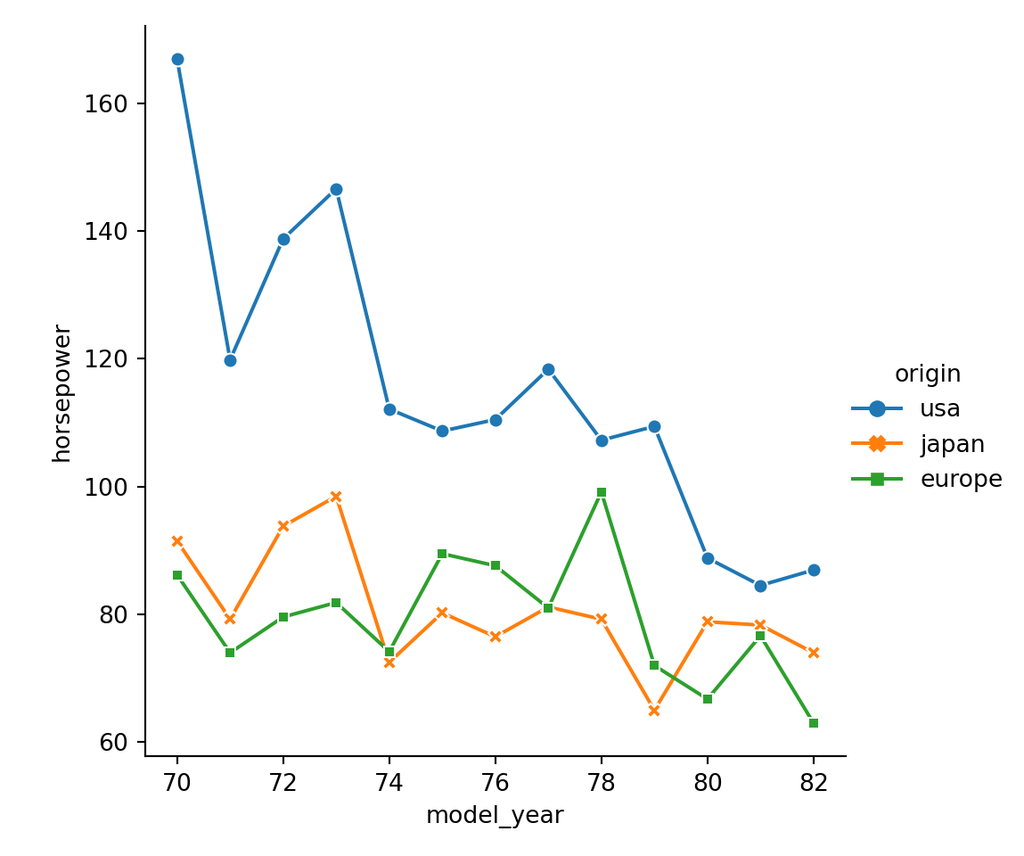

```python
# Add markers and make each line have the same style
g = sns.relplot(x = "model_year", y = "horsepower",
                data = mpg, kind = "line",ci = None, style = "origin",
                hue = "origin", markers = True, dashes = False)

# Show plot
plt.show()
```

Now that we’ve added subgroups, we can see that this downward trend in horsepower was more pronounced among cars from the USA.

# 4 Visualizing a Categorical and a Quantitative Variable

## 4.1 Lecture: Count plots and bar plots

[video not shown]

## 4.2 Count plots

In this exercise, we’ll return to exploring our [**dataset** that contains the responses to a survey sent out to young people. We might suspect that young people spend a lot of time on the internet, but how much do they report using the internet each day? Let’s use a count plot to break down the number of survey responses in each category and then explore whether it changes based on age.](https://raw.githubusercontent.com/QuanNguyenIU/QuanNguyenIU.github.io/main/DataCamp/Python/Intro.%20to%20Data%20Visualization%20with%20Seaborn/survey_data_age.csv)

As a reminder, to create a count plot, we’ll use the catplot() function and specify the name of the categorical variable to count (x=____), the pandas DataFrame to use (data=____), and the type of plot (kind=“count”).

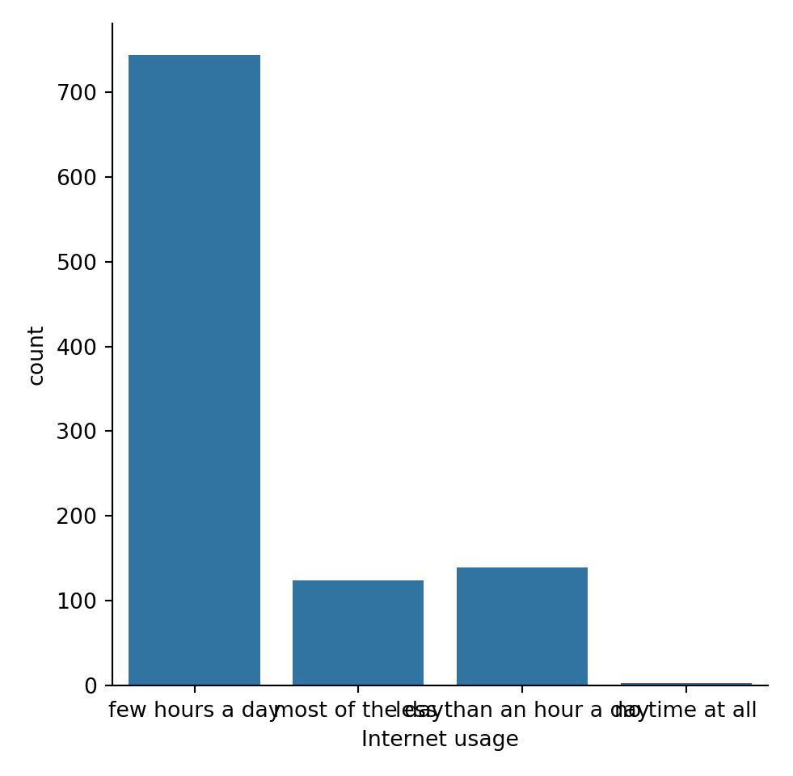

```python
url = 'https://raw.githubusercontent.com/QuanNguyenIU/QuanNguyenIU.github.io/main/DataCamp/Python/Intro.%20to%20Data%20Visualization%20with%20Seaborn/survey_data_age.csv'
survey_data = pd.read_csv(url, sep = ';')

# Create count plot of internet usage
g = sns.catplot(data = survey_data, x = "Internet usage", kind = "count")

# Show plot
plt.show()
```

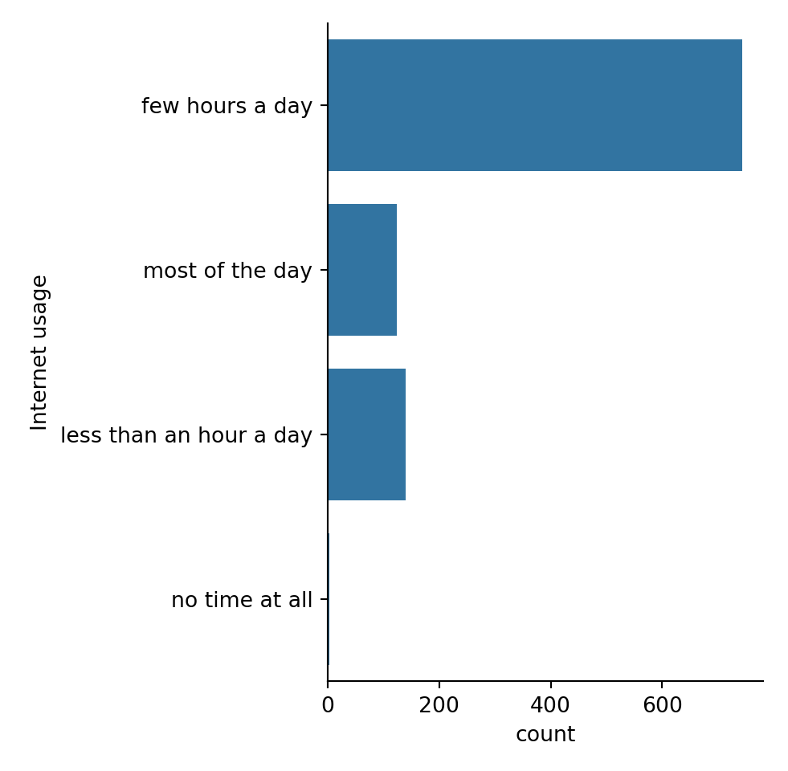

```python
# Change the orientation of the plot
g = sns.catplot(y = "Internet usage", data = survey_data, kind = "count")

# Show plot
plt.show()
```

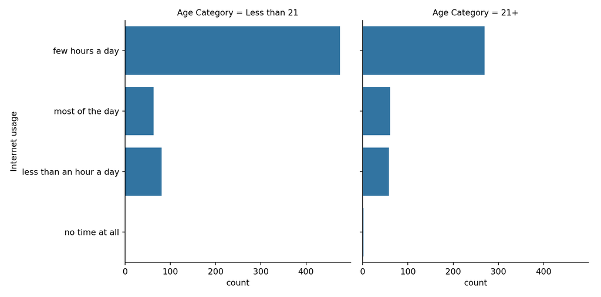

```python
# Separate into column subplots based on age category
g = sns.catplot(y = "Internet usage", data = survey_data,
                kind = "count", col = "Age Category")

# Show plot
plt.show()
```

It looks like most young people use the internet for a few hours every day, regardless of their age.

## 4.3 Bar plots with percentages

Let’s continue exploring the [**responses** to a survey sent out to young people. The variable “Interested in Math” is True if the person reported being interested or very interested in mathematics, and False otherwise. What percentage of young people report being interested in math, and does this vary based on gender? Let’s use a bar plot to find out.](https://raw.githubusercontent.com/QuanNguyenIU/QuanNguyenIU.github.io/main/DataCamp/Python/Intro.%20to%20Data%20Visualization%20with%20Seaborn/survey_data_math.csv)

As a reminder, we’ll create a bar plot using the catplot() function, providing the name of categorical variable to put on the x-axis (x=____), the name of the quantitative variable to summarize on the y-axis (y=____), the pandas DataFrame to use (data=____), and the type of categorical plot (kind=“bar”).

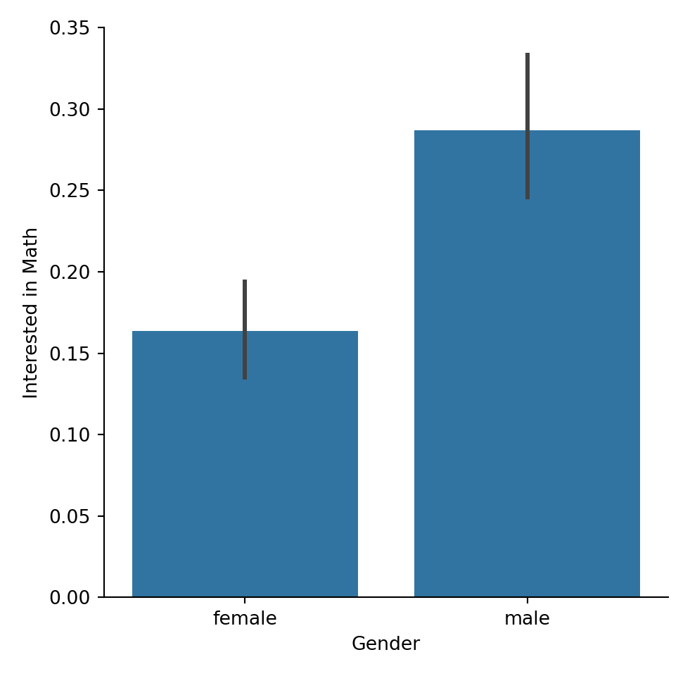

```python
url = 'https://raw.githubusercontent.com/QuanNguyenIU/QuanNguyenIU.github.io/main/DataCamp/Python/Intro.%20to%20Data%20Visualization%20with%20Seaborn/survey_data_math.csv'
survey_data = pd.read_csv(url)

# Create a bar plot of interest in math, separated by gender
g = sns.catplot(data = survey_data,
                x = "Gender", y = "Interested in Math", kind = 'bar')

# Show plot
plt.show()
```

When the y-variable is True/False, bar plots will show the percentage of responses reporting True. This plot shows us that males report a much higher interest in math compared to females.

## 4.4 Customizing bar plots

In this exercise, we’ll explore [**data from students in secondary school**. The “study_time” variable records each student’s reported weekly study time as one of the following categories: “<2 hours”, “2 to 5 hours”, “5 to 10 hours”, or “>10 hours”. Do students who report higher amounts of studying tend to get better final grades? Let’s compare the average final grade among students in each category using a bar plot.](https://raw.githubusercontent.com/QuanNguyenIU/QuanNguyenIU.github.io/main/DataCamp/Python/Intro.%20to%20Data%20Visualization%20with%20Seaborn/survey_data_age.csv)

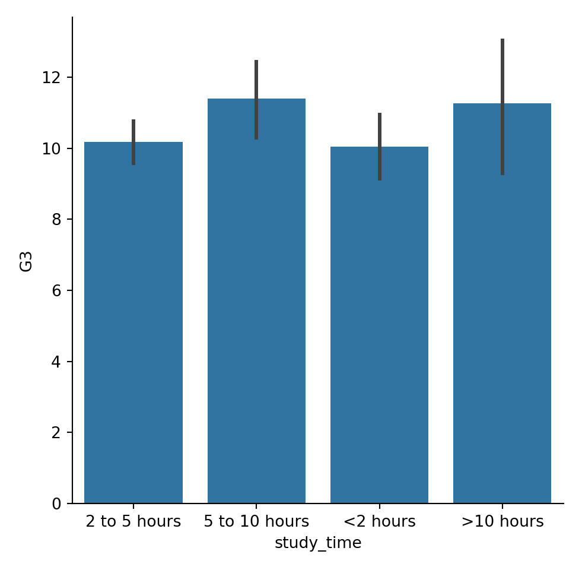

```python
url = 'https://raw.githubusercontent.com/QuanNguyenIU/QuanNguyenIU.github.io/main/DataCamp/Python/Intro.%20to%20Data%20Visualization%20with%20Seaborn/survey_data_age.csv'
survey_data = pd.read_csv(url, sep = ';')

# Create bar plot of average final grade in each study category
g = sns.catplot(data = student_data, x = "study_time", y = "G3", kind = 'bar')

# Show plot
plt.show()
```

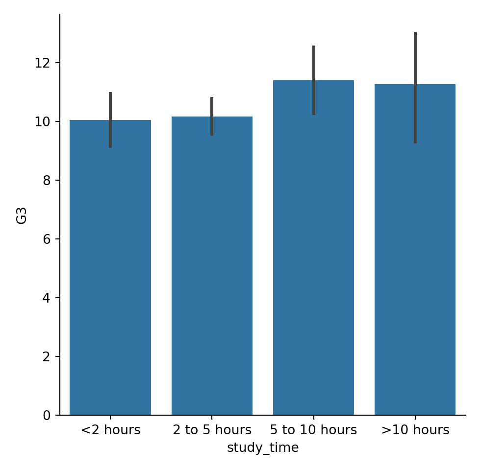

```python
# List of categories from lowest to highest
category_order = ["<2 hours",
                  "2 to 5 hours",
                  "5 to 10 hours",
                  ">10 hours"]

# Rearrange the categories
g = sns.catplot(x = "study_time", y = "G3", data = student_data,
                kind = "bar", order = category_order)

# Show plot
plt.show()
```

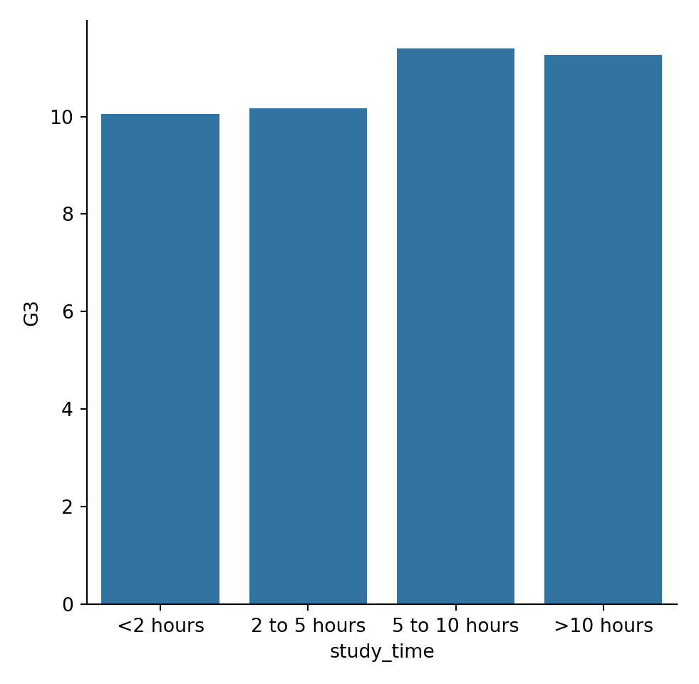

```python
# Hide confidence intervals
g = sns.catplot(x = "study_time", y = "G3", data = student_data,
                kind = "bar", order = category_order, ci = None)

# Show plot
plt.show()
```

Students in our sample who studied more have a slightly higher average grade, but it’s not a strong relationship.

## 4.5 Lecture: Box plots

[video not shown]

## 4.6 Create and interpret a box plot

Let’s continue using the student_data dataset. In an earlier exercise, we explored the relationship between studying and final grade by using a bar plot to compare the average final grade (“G3”) among students in different categories of “study_time”.

In this exercise, we’ll try using a box plot look at this relationship instead. As a reminder, to create a box plot you’ll need to use the catplot() function and specify the name of the categorical variable to put on the x-axis (x=____), the name of the quantitative variable to summarize on the y-axis (y=____), the pandas DataFrame to use (data=____), and the type of plot (kind=“box”).

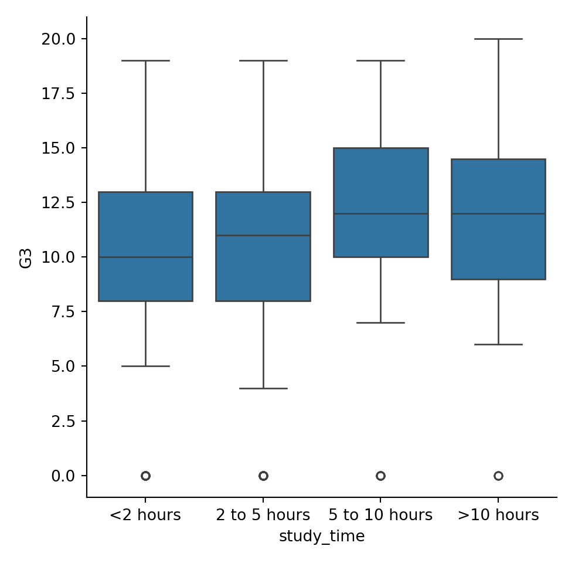

```python
# Specify the category ordering
study_time_order = ["<2 hours", "2 to 5 hours",
                    "5 to 10 hours", ">10 hours"]

# Create a box plot and set the order of the categories
g = sns.catplot(data = student_data, x = "study_time", y = "G3",
                kind = 'box', order = study_time_order)

# Show plot
plt.show()
```

## 4.7 Omitting outliers

Now let’s use the student_data dataset to compare the distribution of final grades (“G3”) between students who have internet access at home and those who don’t. To do this, we’ll use the “internet” variable, which is a binary (yes/no) indicator of whether the student has internet access at home.

Since internet may be less accessible in rural areas, we’ll add subgroups based on where the student lives. For this, we can use the “location” variable, which is an indicator of whether a student lives in an urban (“Urban”) or rural (“Rural”) location.

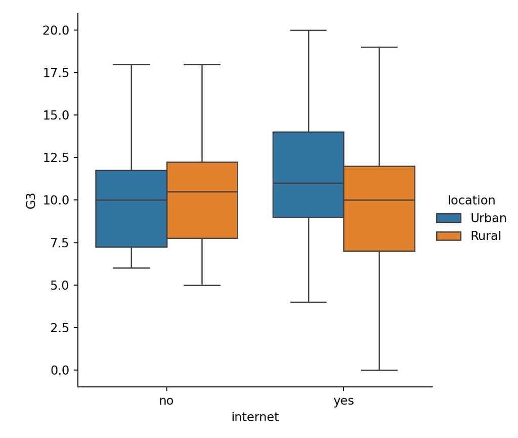

```python
# Create a box plot with subgroups and omit the outliers
g = sns.catplot(data = student_data, x = "internet", y = "G3",
                kind = 'box', hue = "location", showfliers = False)

# Show plot
plt.show()
```

The median grades are quite similar between each group, but the spread of the distribution looks larger among students who have internet access.